# Census Income

# Data Cleaning & Association tests

Read the adult.data and adult.test data and combined both of them together

```r
adultDat <- read.table("adult.data",sep=",")
adultNames <- c("age","workclass","fnlwgt","education","educationnum","maritalstatus","occupation","relationship","race","sex","capitalgain","capitalloss","hoursperweek","nativecountry","Income")
colnames(adultDat) <- adultNames
adultDat1 <- read.table("adult.test",sep = ",",skip = 1)
colnames(adultDat1) <- adultNames
adultDat <- rbind(adultDat,adultDat1)
```

Identified ‘?’ data and removed them from analysis

```r
adultDat[adultDat==' ?'] <- NA
adultDat <- na.omit(adultDat)
str(adultDat)
```

```
## 'data.frame':    45222 obs. of  15 variables:
##  $ age          : int  39 50 38 53 28 37 49 52 31 42 ...
##  $ workclass    : Factor w/ 9 levels " ?"," Federal-gov",..: 8 7 5 5 5 5 5 7 5 5 ...
##  $ fnlwgt       : int  77516 83311 215646 234721 338409 284582 160187 209642 45781 159449 ...
##  $ education    : Factor w/ 16 levels " 10th"," 11th",..: 10 10 12 2 10 13 7 12 13 10 ...
##  $ educationnum : int  13 13 9 7 13 14 5 9 14 13 ...
##  $ maritalstatus: Factor w/ 7 levels " Divorced"," Married-AF-spouse",..: 5 3 1 3 3 3 4 3 5 3 ...
##  $ occupation   : Factor w/ 15 levels " ?"," Adm-clerical",..: 2 5 7 7 11 5 9 5 11 5 ...
##  $ relationship : Factor w/ 6 levels " Husband"," Not-in-family",..: 2 1 2 1 6 6 2 1 2 1 ...
##  $ race         : Factor w/ 5 levels " Amer-Indian-Eskimo",..: 5 5 5 3 3 5 3 5 5 5 ...
##  $ sex          : Factor w/ 2 levels " Female"," Male": 2 2 2 2 1 1 1 2 1 2 ...
##  $ capitalgain  : int  2174 0 0 0 0 0 0 0 14084 5178 ...
##  $ capitalloss  : int  0 0 0 0 0 0 0 0 0 0 ...
##  $ hoursperweek : int  40 13 40 40 40 40 16 45 50 40 ...
##  $ nativecountry: Factor w/ 42 levels " ?"," Cambodia",..: 40 40 40 40 6 40 24 40 40 40 ...
##  $ Income       : Factor w/ 4 levels " <=50K"," >50K",..: 1 1 1 1 1 1 1 2 2 2 ...
##  - attr(*, "na.action")=Class 'omit'  Named int [1:3620] 15 28 39 52 62 70 78 94 107 129 ...
##   .. ..- attr(*, "names")= chr [1:3620] "15" "28" "39" "52" ...
```

Contingency table for education shows different levels of education and corresponding number of records.

```r
table(adultDat$education)
```

```
##
##          10th          11th          12th       1st-4th       5th-6th
##          1223          1619           577           222           449
##       7th-8th           9th    Assoc-acdm     Assoc-voc     Bachelors
##           823           676          1507          1959          7570
##     Doctorate       HS-grad       Masters     Preschool   Prof-school
##           544         14783          2514            72           785
##  Some-college
##          9899
```

The education levels are grouped into subset of groups but still conveying the same meaning as before subsetting.

```r
levels(adultDat$education)
```

```
##  [1] " 10th"         " 11th"         " 12th"         " 1st-4th"
##  [5] " 5th-6th"      " 7th-8th"      " 9th"          " Assoc-acdm"
##  [9] " Assoc-voc"    " Bachelors"    " Doctorate"    " HS-grad"
## [13] " Masters"      " Preschool"    " Prof-school"  " Some-college"
```

```r
levels(adultDat$education) <- c("HSGrad", "HSGrad", "HSGrad","UptoMiddle","UptoMiddle","UptoMiddle","HSGrad","UptoCollege","UptoCollege","Bachelors","Doctorate","HSGrad","Masters","UptoMiddle","UptoCollege","UptoCollege")
table(adultDat$education)
```

```
##
##      HSGrad  UptoMiddle UptoCollege   Bachelors   Doctorate     Masters
##       18878        1566       14150        7570         544        2514
```

Contingency table for working class shows many levels. This can be combined to form fever levels but essentially conveying the same meaning

```r
table(adultDat$workclass)
```

```
##
##                 ?       Federal-gov         Local-gov      Never-worked
##                 0              1406              3100                 0
##           Private      Self-emp-inc  Self-emp-not-inc         State-gov
##             33307              1646              3796              1946
##       Without-pay
##                21
```

The number of records in Never-Worked and Without-pay put together is very low (approx 0.04%), the records are not enough to identify significant impact. Hence they can be removed.

```r
adultDat <- subset(adultDat, (workclass != " Never-worked" & workclass != " Without-pay"))
```

```r
levels(adultDat$workclass)
```

```
## [1] " ?"                " Federal-gov"      " Local-gov"
## [4] " Never-worked"     " Private"          " Self-emp-inc"
## [7] " Self-emp-not-inc" " State-gov"        " Without-pay"
```

```r
levels(adultDat$workclass) <- c("GovEmp", "GovEmp", "GovEmp","Private","Private","SelfEmp","SelfEmp","GovEmp","Private")

table(adultDat$workclass)
```

```
##
##  GovEmp Private SelfEmp
##    6452   33307    5442
```

Contingency table for marital shows many levels. This can be combined to form fever levels but essentially conveying the same meaning

```r
table(adultDat$maritalstatus)
```

```
##
##               Divorced      Married-AF-spouse     Married-civ-spouse
##                   6297                     32                  21042
##  Married-spouse-absent          Never-married              Separated
##                    551                  14592                   1411
##                Widowed
##                   1276
```

```r
levels(adultDat$maritalstatus)
```

```
## [1] " Divorced"              " Married-AF-spouse"
## [3] " Married-civ-spouse"    " Married-spouse-absent"
## [5] " Never-married"         " Separated"
## [7] " Widowed"
```

```r
levels(adultDat$maritalstatus) <- c("NotMarried", "Married", "Married","Married","NotMarried","NotMarried","NotMarried")
table(adultDat$maritalstatus)
```

```
##
## NotMarried    Married
##      23576      21625
```

Armed forces has very limited amount of data that is not useful in showing the impact on entire population. Hence we can remove that from our analysis

```r
table(adultDat$occupation)
```

```
##
##                  ?       Adm-clerical       Armed-Forces
##                  0               5537                 14
##       Craft-repair    Exec-managerial    Farming-fishing
##               6019               5983               1472
##  Handlers-cleaners  Machine-op-inspct      Other-service
##               2044               2968               4806
##    Priv-house-serv     Prof-specialty    Protective-serv
##                232               6008                976
##              Sales       Tech-support   Transport-moving
##               5407               1420               2315
```

```r
levels(adultDat$occupation)
```

```
##  [1] " ?"                 " Adm-clerical"      " Armed-Forces"
##  [4] " Craft-repair"      " Exec-managerial"   " Farming-fishing"
##  [7] " Handlers-cleaners" " Machine-op-inspct" " Other-service"
## [10] " Priv-house-serv"   " Prof-specialty"    " Protective-serv"
## [13] " Sales"             " Tech-support"      " Transport-moving"
```

```r
adultDat <- subset(adultDat, (occupation != " Armed-Forces"))
levels(adultDat$occupation) <- c("Sales", "Admclerical","Sales","Craftrepair","Execmanagerial", " Farmingfishing", " Handlerscleaners"," Machineopinspct"," Otherservice","Privhouseserv", " Profspecialty", "Protectiveserv", "Sales", " Techsupport","Transportmoving" )
```

```r
table(adultDat$relationship)
```

```
##
##         Husband   Not-in-family  Other-relative       Own-child
##           18653           11697            1347            6616
##       Unmarried            Wife
##            4786            2088
```

```r
table(adultDat$race)
```

```
##
##  Amer-Indian-Eskimo  Asian-Pac-Islander               Black
##                 434                1302                4226
##               Other               White
##                 353               38872
```

```r
table(adultDat$sex)
```

```
##
##  Female    Male
##   14688   30499
```

Country has many levels for a categorical variable. Grouping the country based on location into continents would be ideal.

```r
table(adultDat$nativecountry)
```

```
##
##                           ?                    Cambodia
##                           0                          26
##                      Canada                       China
##                         163                         113
##                    Columbia                        Cuba
##                          82                         133
##          Dominican-Republic                     Ecuador
##                          97                          43
##                 El-Salvador                     England
##                         147                         119
##                      France                     Germany
##                          36                         193
##                      Greece                   Guatemala
##                          49                          86
##                       Haiti          Holand-Netherlands
##                          69                           1
##                    Honduras                        Hong
##                          19                          28
##                     Hungary                       India
##                          18                         147
##                        Iran                     Ireland
##                          56                          36
##                       Italy                     Jamaica
##                         100                         103
##                       Japan                        Laos
##                          89                          21
##                      Mexico                   Nicaragua
##                         903                          48
##  Outlying-US(Guam-USVI-etc)                        Peru
##                          22                          45
##                 Philippines                      Poland
##                         282                          81
##                    Portugal                 Puerto-Rico
##                          62                         175
##                    Scotland                       South
##                          20                         101
##                      Taiwan                    Thailand
##                          55                          29
##             Trinadad&Tobago               United-States
##                          26                       41258
##                     Vietnam                  Yugoslavia
##                          83                          23
```

```r
levels(adultDat$nativecountry)
```

```
##  [1] " ?"                          " Cambodia"
##  [3] " Canada"                     " China"
##  [5] " Columbia"                   " Cuba"
##  [7] " Dominican-Republic"         " Ecuador"
##  [9] " El-Salvador"                " England"
## [11] " France"                     " Germany"
## [13] " Greece"                     " Guatemala"
## [15] " Haiti"                      " Holand-Netherlands"
## [17] " Honduras"                   " Hong"
## [19] " Hungary"                    " India"
## [21] " Iran"                       " Ireland"
## [23] " Italy"                      " Jamaica"
## [25] " Japan"                      " Laos"
## [27] " Mexico"                     " Nicaragua"
## [29] " Outlying-US(Guam-USVI-etc)" " Peru"
## [31] " Philippines"                " Poland"
## [33] " Portugal"                   " Puerto-Rico"
## [35] " Scotland"                   " South"
## [37] " Taiwan"                     " Thailand"
## [39] " Trinadad&Tobago"            " United-States"
## [41] " Vietnam"                    " Yugoslavia"
```

```r
levels(adultDat$nativecountry) <- c("Asia","Asia","NorthAmerica","Asia","SouthAmerica","NorthAmerica","NorthAmerica","SouthAmerica","NorthAmerica","Europe","Europe","Europe","Europe","Europe","NorthAmerica","NorthAmerica","Europe","NorthAmerica","Asia","Europe","Asia","Asia","Europe","Europe","NorthAmerica","Asia","Asia","NorthAmerica","NorthAmerica","NorthAmerica","SouthAmerica","Asia","Europe","Europe","NorthAmerica","Europe","Asia","Asia","Asia","NorthAmerica","NorthAmerica","Asia","Europe")
```

```r
table(adultDat$nativecountry)
```

```
##
##         Asia NorthAmerica SouthAmerica       Europe
##         1387        42203          407         1190
```

converting different representation of Income variable into one form.

```r
levels(adultDat$Income)
```

```
## [1] " <=50K"  " >50K"   " <=50K." " >50K."
```

```r
levels(adultDat$Income) <- c("0", "1", "0","1")
table(adultDat$Income)
```

```
##
##     0     1
## 33985 11202
```

Out of total of 45187 observations Capital loss has 97 unique records and 43049 records with value 0. The outcome will have very little influence over difference in values rather than 0. i.e., the value 0 will dominate the model in analysis and other values have very little influence over the entire model. We could potentially remove this column without having much impact on the final model. Let us check that with model accuracy.

```r
nrow(adultDat[adultDat$capitalloss==0,])
```

```
## [1] 43049
```

```r
length(unique(adultDat$capitalloss))
```

```
## [1] 97
```

The above observation stands for capitalgain as well.

```r
nrow(adultDat[adultDat$capitalgain==0,])
```

```
## [1] 41400
```

```r
length(unique(adultDat$capitalgain))
```

```
## [1] 121
```

Some variables are slightly skewed indicating scope for transformation.

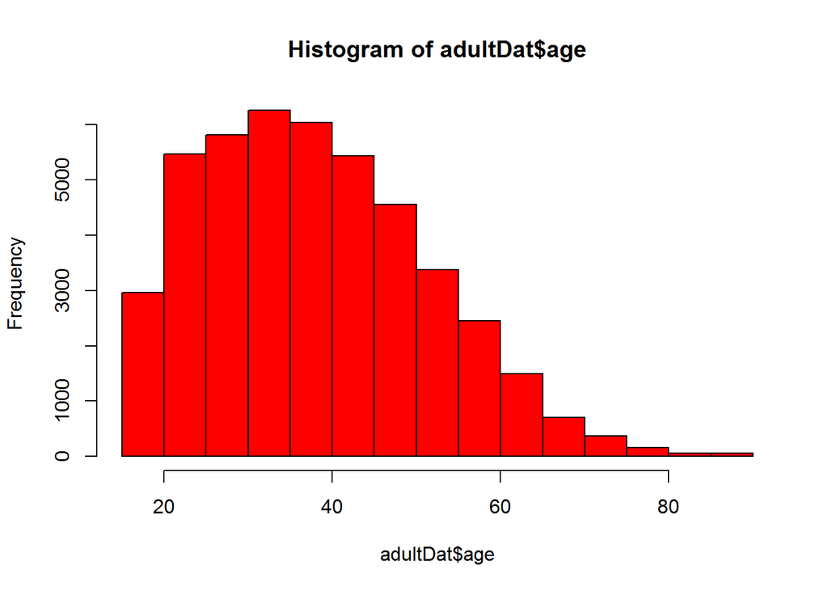

```r
hist(adultDat$age,col=2)
```

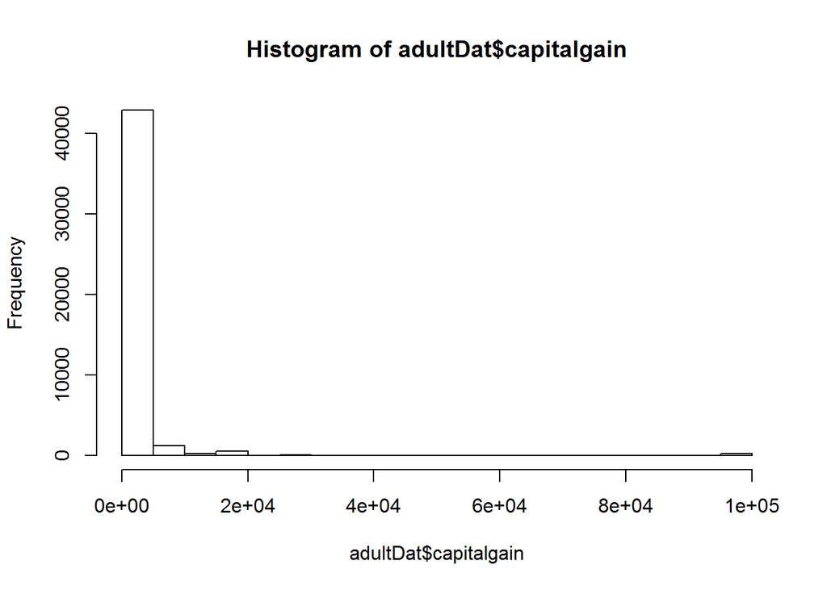

```r
hist(adultDat$capitalgain)
```

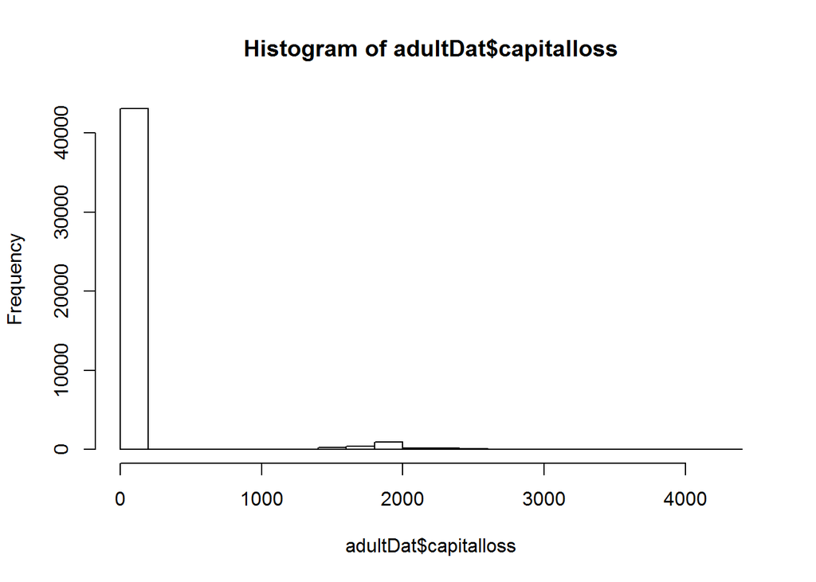

```r
hist(adultDat$capitalloss)
```

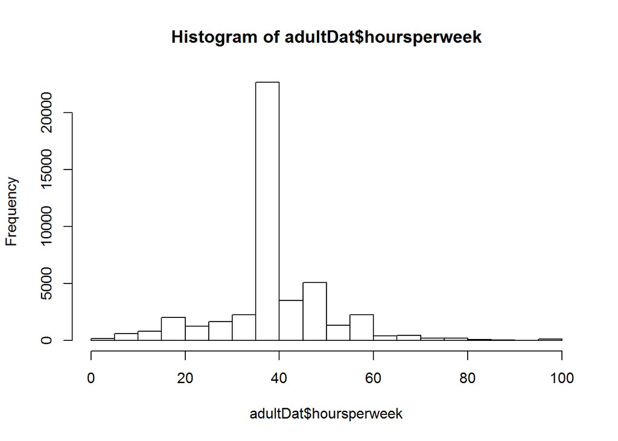

```r
hist(adultDat$hoursperweek)
```

The chi square test proves that workclass, education, marital status, relationship, race and sex are associated with outcome Income variable

```r
chisq.test(adultDat$workclass,adultDat$Income)
```

```
##
##  Pearson's Chi-squared test
##
## data:  adultDat$workclass and adultDat$Income
## X-squared = 666.97, df = 2, p-value < 2.2e-16
```

```r
chisq.test(adultDat$education,adultDat$Income)
```

```
##
##  Pearson's Chi-squared test
##
## data:  adultDat$education and adultDat$Income
## X-squared = 4608.9, df = 5, p-value < 2.2e-16
```

```r
chisq.test(adultDat$maritalstatus,adultDat$Income)
```

```
##
##  Pearson's Chi-squared test with Yates' continuity correction
##
## data:  adultDat$maritalstatus and adultDat$Income
## X-squared = 8656.8, df = 1, p-value < 2.2e-16
```

```r
chisq.test(adultDat$relationship,adultDat$Income)
```

```
##
##  Pearson's Chi-squared test
##
## data:  adultDat$relationship and adultDat$Income
## X-squared = 9354, df = 5, p-value < 2.2e-16
```

```r
chisq.test(adultDat$race,adultDat$Income)
```

```
##
##  Pearson's Chi-squared test
##
## data:  adultDat$race and adultDat$Income
## X-squared = 451.89, df = 4, p-value < 2.2e-16
```

```r
chisq.test(adultDat$sex,adultDat$Income)
```

```
##
##  Pearson's Chi-squared test with Yates' continuity correction
##
## data:  adultDat$sex and adultDat$Income
## X-squared = 2105.4, df = 1, p-value < 2.2e-16
```

fnlwgt has 26725 unique records and is not related to the dataset, Hence it can be removed from the analysis.

```r
length(unique(adultDat$fnlwgt))
```

```
## [1] 26725
```

Education number is a numeric representation of education categorical variable. Both convey the same meaning, hence it can be removed

```r
adultDat_Final <- adultDat[,-c(3,5)]
```

The P values against each continues variable in logistic regression show that the variables are significant towards the Income variable

```r
glm.fits <- glm(adultDat_Final$Income~adultDat$age+adultDat$capitalgain+adultDat$capitalloss+adultDat$hoursperweek,data = adultDat_Final,family = binomial)
summary(glm.fits)
```

```
##
## Call:
## glm(formula = adultDat_Final$Income ~ adultDat$age + adultDat$capitalgain +
##     adultDat$capitalloss + adultDat$hoursperweek, family = binomial,
##     data = adultDat_Final)
##
## Deviance Residuals:
##     Min       1Q   Median       3Q      Max
## -5.2912  -0.6923  -0.5108  -0.2152   2.6344
##
## Coefficients:
##                         Estimate Std. Error z value Pr(>|z|)
## (Intercept)           -4.826e+00  6.622e-02  -72.87   <2e-16 ***
## adultDat$age           3.908e-02  9.641e-04   40.53   <2e-16 ***
## adultDat$capitalgain   3.278e-04  7.623e-06   43.00   <2e-16 ***
## adultDat$capitalloss   7.620e-04  2.532e-05   30.09   <2e-16 ***
## adultDat$hoursperweek  4.305e-02  1.085e-03   39.69   <2e-16 ***
## ---
## Signif. codes:  0 '***' 0.001 '**' 0.01 '*' 0.05 '.' 0.1 ' ' 1
##
## (Dispersion parameter for binomial family taken to be 1)
##
##     Null deviance: 50611  on 45186  degrees of freedom
## Residual deviance: 41287  on 45182  degrees of freedom
## AIC: 41297
##
## Number of Fisher Scoring iterations: 6
```

Using Model.Matrix to convert categorical values into dummy variables for PCA analysis. The first column, which is an intercept has to be removed. The input is scaled for PCA.

```r
mmodel.mt = model.matrix(~.,adultDat_Final)
mmodel.mt1=mmodel.mt[,-c(1)]
pc.t = prcomp(mmodel.mt1,scale=T)
```

The below graph shows the first two principal components and data points representing sex is represented using colors.

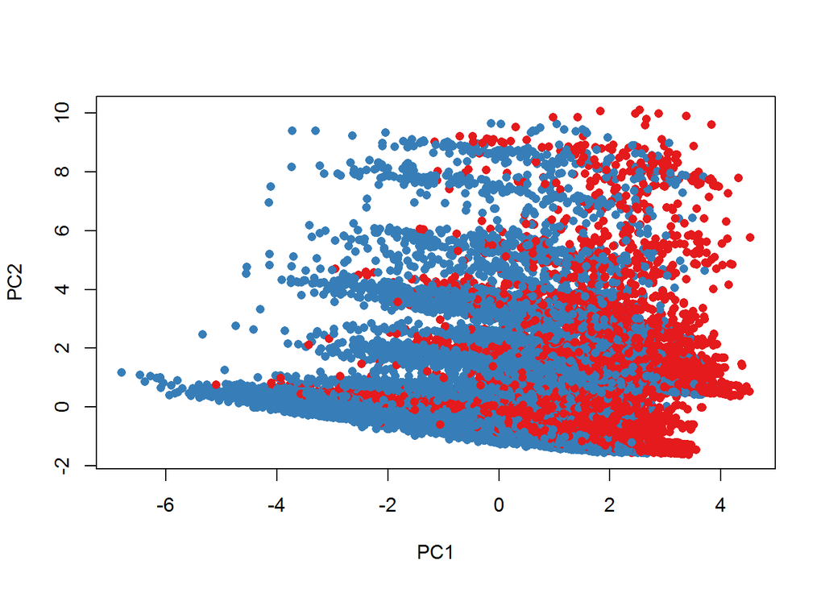

```r
cols<-brewer.pal(n=3,name="Set1")
cols_t1<-cols[adultDat_Final$sex]
plot(pc.t$x[,1:2],col = cols_t1,pch=16)
```

```r
#model.matrix(~ workclass+education+maritalstatus+race+sex+nativecountry, data=adultDat,
#    contrasts.arg=list(workclass=diag(nlevels(adultDat$workclass)), education=diag(nlevels(adultDat$education)),maritalstatus=diag(nlevels(adultDat$maritalstatus)), #race=diag(nlevels(adultDat$race)),sex=diag(nlevels(adultDat$sex)),nativecountry=diag(nlevels(adultDat$nativecountry))))
```

```r
cor(adultDat_Final[,c(1,9,10,11)])
```

```
##                    age capitalgain capitalloss hoursperweek
## age          1.0000000  0.07974500  0.05930600   0.10215522
## capitalgain  0.0797450  1.00000000 -0.03210296   0.08389618
## capitalloss  0.0593060 -0.03210296  1.00000000   0.05421560
## hoursperweek 0.1021552  0.08389618  0.05421560   1.00000000
```

# Logistic regression:

```r
glmRes <- glm(Income~.,family= binomial(link='logit'),data=adultDat_Final)
summary(glmRes)
```

```
##
## Call:
## glm(formula = Income ~ ., family = binomial(link = "logit"),
##     data = adultDat_Final)
##
## Deviance Residuals:
##     Min       1Q   Median       3Q      Max
## -5.2769  -0.5360  -0.2062  -0.0338   3.5510
##
## Coefficients:
##                               Estimate Std. Error z value Pr(>|z|)
## (Intercept)                 -6.165e+00  2.803e-01 -21.995  < 2e-16 ***
## age                          2.675e-02  1.316e-03  20.321  < 2e-16 ***
## workclassPrivate             2.113e-02  4.364e-02   0.484 0.628300
## workclassSelfEmp            -2.286e-01  5.630e-02  -4.060 4.92e-05 ***
## educationUptoMiddle         -1.220e+00  1.258e-01  -9.702  < 2e-16 ***
## educationUptoCollege         5.904e-01  3.689e-02  16.006  < 2e-16 ***
## educationBachelors           1.132e+00  4.445e-02  25.471  < 2e-16 ***
## educationDoctorate           1.861e+00  1.300e-01  14.321  < 2e-16 ***
## educationMasters             1.378e+00  6.477e-02  21.279  < 2e-16 ***
## maritalstatusMarried         1.039e+00  1.330e-01   7.809 5.79e-15 ***
## occupationAdmclerical       -1.962e-01  6.624e-02  -2.961 0.003062 **
## occupationCraftrepair       -2.670e-01  5.540e-02  -4.820 1.43e-06 ***
## occupationExecmanagerial     5.561e-01  5.309e-02  10.474  < 2e-16 ***
## occupation Farmingfishing   -1.453e+00  1.068e-01 -13.609  < 2e-16 ***
## occupation Handlerscleaners -1.025e+00  1.101e-01  -9.314  < 2e-16 ***
## occupation Machineopinspct  -6.151e-01  7.681e-02  -8.007 1.17e-15 ***
## occupation Otherservice     -1.229e+00  9.314e-02 -13.191  < 2e-16 ***
## occupationPrivhouseserv     -2.081e+00  7.275e-01  -2.861 0.004220 **
## occupation Profspecialty     4.372e-01  5.684e-02   7.692 1.44e-14 ***
## occupationProtectiveserv     1.254e-01  9.814e-02   1.278 0.201219
## occupation Techsupport       3.260e-01  8.503e-02   3.834 0.000126 ***
## occupationTransportmoving   -4.465e-01  7.330e-02  -6.092 1.12e-09 ***
## relationship Not-in-family  -9.554e-01  1.348e-01  -7.089 1.35e-12 ***
## relationship Other-relative -1.392e+00  1.879e-01  -7.407 1.29e-13 ***
## relationship Own-child      -2.046e+00  1.669e-01 -12.259  < 2e-16 ***
## relationship Unmarried      -1.027e+00  1.497e-01  -6.862 6.78e-12 ***
## relationship Wife            1.087e+00  8.428e-02  12.903  < 2e-16 ***
## race Asian-Pac-Islander      7.489e-01  2.055e-01   3.644 0.000269 ***
## race Black                   4.261e-01  1.910e-01   2.231 0.025683 *
## race Other                   3.983e-01  2.762e-01   1.442 0.149307
## race White                   6.400e-01  1.821e-01   3.514 0.000441 ***
## sex Male                     7.258e-01  6.367e-02  11.398  < 2e-16 ***
## capitalgain                  3.184e-04  8.588e-06  37.070  < 2e-16 ***
## capitalloss                  6.587e-04  3.067e-05  21.477  < 2e-16 ***
## hoursperweek                 3.052e-02  1.347e-03  22.657  < 2e-16 ***
## nativecountryNorthAmerica    4.500e-01  1.095e-01   4.111 3.94e-05 ***
## nativecountrySouthAmerica    3.558e-01  1.922e-01   1.851 0.064151 .
## nativecountryEurope          3.861e-01  1.375e-01   2.808 0.004985 **
## ---
## Signif. codes:  0 '***' 0.001 '**' 0.01 '*' 0.05 '.' 0.1 ' ' 1
##
## (Dispersion parameter for binomial family taken to be 1)
##
##     Null deviance: 50611  on 45186  degrees of freedom
## Residual deviance: 29985  on 45149  degrees of freedom
## AIC: 30061
##
## Number of Fisher Scoring iterations: 7
```

We test for nativecountry and the P-Value is less than 0.05 so we reject the null hypothesis that reduce model is better. Hence native country is relevant

```r
glmRes_nativecountry <- glm(Income~age+workclass+education+maritalstatus+occupation+relationship+race+sex+capitalgain+capitalloss+hoursperweek,family= binomial(link='logit'),data=adultDat_Final)
lrtest(glmRes, glmRes_nativecountry)
```

```
## Likelihood ratio test
##
## Model 1: Income ~ age + workclass + education + maritalstatus + occupation +
##     relationship + race + sex + capitalgain + capitalloss + hoursperweek +
##     nativecountry
## Model 2: Income ~ age + workclass + education + maritalstatus + occupation +
##     relationship + race + sex + capitalgain + capitalloss + hoursperweek
##   #Df LogLik Df  Chisq Pr(>Chisq)
## 1  38 -14992
## 2  35 -15001 -3 17.796  0.0004846 ***
## ---
## Signif. codes:  0 '***' 0.001 '**' 0.01 '*' 0.05 '.' 0.1 ' ' 1
```

```r
glmRes_capitalloss<- glm(Income~age+workclass+education+maritalstatus+occupation+relationship+race+sex+capitalgain+hoursperweek+nativecountry,family= binomial(link='logit'),data=adultDat_Final)
lrtest(glmRes, glmRes_capitalloss)
```

```
## Likelihood ratio test
##
## Model 1: Income ~ age + workclass + education + maritalstatus + occupation +
##     relationship + race + sex + capitalgain + capitalloss + hoursperweek +
##     nativecountry
## Model 2: Income ~ age + workclass + education + maritalstatus + occupation +
##     relationship + race + sex + capitalgain + hoursperweek +
##     nativecountry
##   #Df LogLik Df  Chisq Pr(>Chisq)
## 1  38 -14992
## 2  37 -15230 -1 474.39  < 2.2e-16 ***
## ---
## Signif. codes:  0 '***' 0.001 '**' 0.01 '*' 0.05 '.' 0.1 ' ' 1
```

```r
glmRes_hoursperweek<- glm(Income~age+workclass+education+maritalstatus+occupation+relationship+race+sex+capitalgain+capitalloss+nativecountry,family= binomial(link='logit'),data=adultDat_Final)
lrtest(glmRes, glmRes_hoursperweek)
```

```
## Likelihood ratio test
##
## Model 1: Income ~ age + workclass + education + maritalstatus + occupation +
##     relationship + race + sex + capitalgain + capitalloss + hoursperweek +
##     nativecountry
## Model 2: Income ~ age + workclass + education + maritalstatus + occupation +
##     relationship + race + sex + capitalgain + capitalloss + nativecountry
##   #Df LogLik Df Chisq Pr(>Chisq)
## 1  38 -14992
## 2  37 -15256 -1 527.8  < 2.2e-16 ***
## ---
## Signif. codes:  0 '***' 0.001 '**' 0.01 '*' 0.05 '.' 0.1 ' ' 1
```

```r
glmRes_capitalgain<- glm(Income~age+workclass+education+maritalstatus+occupation+relationship+race+sex+hoursperweek+capitalloss+nativecountry,family= binomial(link='logit'),data=adultDat_Final)
lrtest(glmRes, glmRes_capitalgain)
```

```
## Likelihood ratio test
##
## Model 1: Income ~ age + workclass + education + maritalstatus + occupation +
##     relationship + race + sex + capitalgain + capitalloss + hoursperweek +
##     nativecountry
## Model 2: Income ~ age + workclass + education + maritalstatus + occupation +
##     relationship + race + sex + hoursperweek + capitalloss +
##     nativecountry
##   #Df LogLik Df  Chisq Pr(>Chisq)
## 1  38 -14992
## 2  37 -16385 -1 2786.1  < 2.2e-16 ***
## ---
## Signif. codes:  0 '***' 0.001 '**' 0.01 '*' 0.05 '.' 0.1 ' ' 1
```

```r
glmRes_sex<- glm(Income~age+workclass+education+maritalstatus+occupation+relationship+race+capitalgain+hoursperweek+capitalloss+nativecountry,family= binomial(link='logit'),data=adultDat_Final)
lrtest(glmRes, glmRes_sex)
```

```
## Likelihood ratio test
##
## Model 1: Income ~ age + workclass + education + maritalstatus + occupation +
##     relationship + race + sex + capitalgain + capitalloss + hoursperweek +
##     nativecountry
## Model 2: Income ~ age + workclass + education + maritalstatus + occupation +
##     relationship + race + capitalgain + hoursperweek + capitalloss +
##     nativecountry
##   #Df LogLik Df Chisq Pr(>Chisq)
## 1  38 -14992
## 2  37 -15059 -1   133  < 2.2e-16 ***
## ---
## Signif. codes:  0 '***' 0.001 '**' 0.01 '*' 0.05 '.' 0.1 ' ' 1
```

```r
glmRes_race<- glm(Income~age+workclass+education+maritalstatus+occupation+relationship+sex+capitalgain+hoursperweek+capitalloss+nativecountry,family= binomial(link='logit'),data=adultDat_Final)
lrtest(glmRes, glmRes_race)
```

```
## Likelihood ratio test
##
## Model 1: Income ~ age + workclass + education + maritalstatus + occupation +
##     relationship + race + sex + capitalgain + capitalloss + hoursperweek +
##     nativecountry
## Model 2: Income ~ age + workclass + education + maritalstatus + occupation +
##     relationship + sex + capitalgain + hoursperweek + capitalloss +
##     nativecountry
##   #Df LogLik Df  Chisq Pr(>Chisq)
## 1  38 -14992
## 2  34 -15006 -4 27.749  1.402e-05 ***
## ---
## Signif. codes:  0 '***' 0.001 '**' 0.01 '*' 0.05 '.' 0.1 ' ' 1
```

```r
glmRes_relationship<- glm(Income~age+workclass+education+maritalstatus+occupation+race+sex+capitalgain+hoursperweek+capitalloss+nativecountry,family= binomial(link='logit'),data=adultDat_Final)
lrtest(glmRes, glmRes_relationship)
```

```
## Likelihood ratio test
##
## Model 1: Income ~ age + workclass + education + maritalstatus + occupation +
##     relationship + race + sex + capitalgain + capitalloss + hoursperweek +
##     nativecountry
## Model 2: Income ~ age + workclass + education + maritalstatus + occupation +
##     race + sex + capitalgain + hoursperweek + capitalloss + nativecountry
##   #Df LogLik Df  Chisq Pr(>Chisq)
## 1  38 -14992
## 2  33 -15228 -5 470.84  < 2.2e-16 ***
## ---
## Signif. codes:  0 '***' 0.001 '**' 0.01 '*' 0.05 '.' 0.1 ' ' 1
```

```r
glmRes_occupation<- glm(Income~age+workclass+education+maritalstatus+relationship+race+sex+capitalgain+hoursperweek+capitalloss+nativecountry,family= binomial(link='logit'),data=adultDat_Final)
lrtest(glmRes, glmRes_occupation)
```

```
## Likelihood ratio test
##
## Model 1: Income ~ age + workclass + education + maritalstatus + occupation +
##     relationship + race + sex + capitalgain + capitalloss + hoursperweek +
##     nativecountry
## Model 2: Income ~ age + workclass + education + maritalstatus + relationship +
##     race + sex + capitalgain + hoursperweek + capitalloss + nativecountry
##   #Df LogLik  Df  Chisq Pr(>Chisq)
## 1  38 -14992
## 2  26 -15545 -12 1104.7  < 2.2e-16 ***
## ---
## Signif. codes:  0 '***' 0.001 '**' 0.01 '*' 0.05 '.' 0.1 ' ' 1
```

```r
glmRes_maritalstatus<- glm(Income~age+workclass+education+occupation+relationship+race+sex+capitalgain+hoursperweek+capitalloss+nativecountry,family= binomial(link='logit'),data=adultDat_Final)
lrtest(glmRes, glmRes_maritalstatus)
```

```
## Likelihood ratio test
##
## Model 1: Income ~ age + workclass + education + maritalstatus + occupation +
##     relationship + race + sex + capitalgain + capitalloss + hoursperweek +
##     nativecountry
## Model 2: Income ~ age + workclass + education + occupation + relationship +
##     race + sex + capitalgain + hoursperweek + capitalloss + nativecountry
##   #Df LogLik Df Chisq Pr(>Chisq)
## 1  38 -14992
## 2  37 -15019 -1 53.01  3.318e-13 ***
## ---
## Signif. codes:  0 '***' 0.001 '**' 0.01 '*' 0.05 '.' 0.1 ' ' 1
```

```r
glmRes_education<- glm(Income~age+workclass+maritalstatus+occupation+relationship+race+sex+capitalgain+hoursperweek+capitalloss+nativecountry,family= binomial(link='logit'),data=adultDat_Final)
lrtest(glmRes, glmRes_education)
```

```
## Likelihood ratio test
##
## Model 1: Income ~ age + workclass + education + maritalstatus + occupation +
##     relationship + race + sex + capitalgain + capitalloss + hoursperweek +
##     nativecountry
## Model 2: Income ~ age + workclass + maritalstatus + occupation + relationship +
##     race + sex + capitalgain + hoursperweek + capitalloss + nativecountry
##   #Df LogLik Df  Chisq Pr(>Chisq)
## 1  38 -14992
## 2  33 -15537 -5 1089.8  < 2.2e-16 ***
## ---
## Signif. codes:  0 '***' 0.001 '**' 0.01 '*' 0.05 '.' 0.1 ' ' 1
```

```r
glmRes_workclass<- glm(Income~age+education+maritalstatus+occupation+relationship+race+sex+capitalgain+hoursperweek+capitalloss+nativecountry,family= binomial(link='logit'),data=adultDat_Final)
lrtest(glmRes, glmRes_workclass)
```

```
## Likelihood ratio test
##
## Model 1: Income ~ age + workclass + education + maritalstatus + occupation +
##     relationship + race + sex + capitalgain + capitalloss + hoursperweek +
##     nativecountry
## Model 2: Income ~ age + education + maritalstatus + occupation + relationship +
##     race + sex + capitalgain + hoursperweek + capitalloss + nativecountry
##   #Df LogLik Df  Chisq Pr(>Chisq)
## 1  38 -14992
## 2  36 -15009 -2 33.558  5.163e-08 ***
## ---
## Signif. codes:  0 '***' 0.001 '**' 0.01 '*' 0.05 '.' 0.1 ' ' 1
```

```r
glmRes_age<- glm(Income~workclass+education+maritalstatus+occupation+relationship+race+sex+capitalgain+hoursperweek+capitalloss+nativecountry,family= binomial(link='logit'),data=adultDat_Final)
lrtest(glmRes, glmRes_age)
```

```
## Likelihood ratio test
##
## Model 1: Income ~ age + workclass + education + maritalstatus + occupation +
##     relationship + race + sex + capitalgain + capitalloss + hoursperweek +
##     nativecountry
## Model 2: Income ~ workclass + education + maritalstatus + occupation +
##     relationship + race + sex + capitalgain + hoursperweek +
##     capitalloss + nativecountry
##   #Df LogLik Df Chisq Pr(>Chisq)
## 1  38 -14992
## 2  37 -15200 -1 416.3  < 2.2e-16 ***
## ---
## Signif. codes:  0 '***' 0.001 '**' 0.01 '*' 0.05 '.' 0.1 ' ' 1
```

From the likelihood ratio tests performed above the highest impact variables are the ones with least P value age, education, occupation, relationship, sex, capitalgain, capitalloss.

The below method calculates Accuracy, Sensitivity and Specificity. This method will be reused in the below code

```r
assess.prediction=function(truth,predicted){
  predited = predicted[!is.na(truth)]
  truth = truth[!is.na(truth)]
  truth = truth[!is.na(predicted)]
  predicted = predicted[!is.na(predicted)]

  TP = sum(truth==1 & predicted==1)
  TN = sum(truth==0 & predicted==0)
  FP = sum(truth==0 & predicted==1)
  FN = sum(truth==1 & predicted==0)

  P = TP+FN
  N = FP+TN

  acc = sum(truth == predicted)/length(truth)
  Sens = TP/P
  Spec = TN/N
  return(list(acc,Sens,Spec))


}
```

Cross validation is performed with split ratio of .75 to .25 for training and testing dataset. The results are captured in Fullres data frame.

```r
Train.Results <- data.frame("acc"=integer(0),"Sens"=integer(0),"Spec"=integer(0))
Test.Results <- data.frame("acc"=integer(0),"Sens"=integer(0),"Spec"=integer(0))
Fullres<- NULL
nTries <- 30
for ( iTry in 1:nTries ) {
  Split <- sample.split(adultDat_Final$Income, SplitRatio = 0.75)
  Trainadult <- subset(adultDat_Final, Split == TRUE)
  Testadult <- subset(adultDat_Final, Split == FALSE)
  glmRes <- glm(Income~.,data=Trainadult,family="binomial")
  pred = predict(glmRes,Trainadult,type="response")
  predtest = predict(glmRes,Testadult,type="response")

  test <- assess.prediction(Trainadult$Income,ifelse(pred>0.5,1,0))
  Train.Results[nrow(Train.Results)+1,] <- c(test[[1]],test[[2]],test[[3]])

  test1<-   assess.prediction(Testadult$Income,ifelse(predtest>0.5,1,0))
  Test.Results[nrow(Test.Results)+1,] <- c(test1[[1]],test1[[2]],test1[[3]])

  Fullres <- rbind(Fullres,data.frame(vars=iTry,sel="acc",val=c(test[[1]],test1[[1]]),traintest=c("Train","Test")))
  Fullres <- rbind(Fullres,data.frame(vars=iTry,sel="Sens",val=c(test[[2]],test1[[2]]),traintest=c("Train","Test")))
  Fullres <- rbind(Fullres,data.frame(vars=iTry,sel="Spec",val=c(test[[3]],test1[[3]]),traintest=c("Train","Test")))
}
```

[output not shown]

Accuracy, Sensitivity and Specificity are plotted in the graph below for each iteration of cross validation.

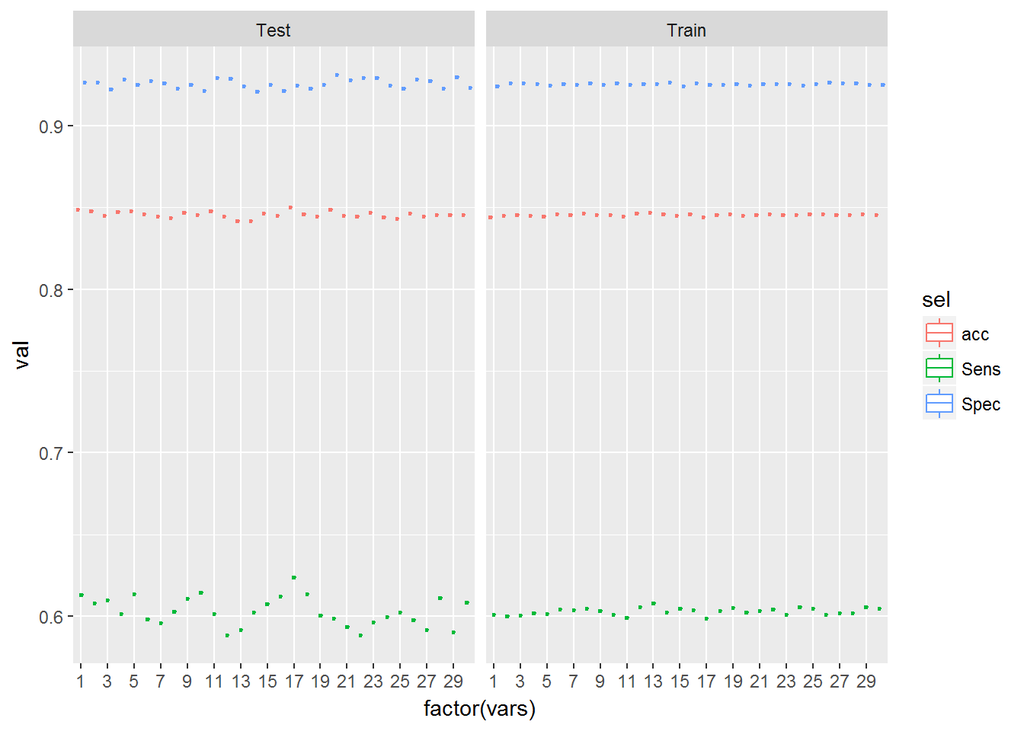

```r
ggplot(Fullres,aes(x=factor(vars),y=val,colour=sel)) + geom_boxplot()+facet_wrap(~traintest)+scale_x_discrete(breaks = seq(1, 30, by = 2))
```

Calculating the average Accuracy, Sensitivity and Specificity for Training and Testing data set.

```r
Train_avg_acc <- signif(sum(subset(Fullres,(traintest == "Train"&sel=="acc"))$val)*100/nTries,3)
Train_avg_sens <- signif(sum(subset(Fullres,(traintest == "Train"&sel=="Sens"))$val)*100/nTries,3)
Train_avg_spec <- signif(sum(subset(Fullres,(traintest == "Train"&sel=="Spec"))$val)*100/nTries,3)

Test_avg_acc <- signif(sum(subset(Fullres,(traintest == "Test"&sel=="acc"))$val)*100/nTries,3)
Test_avg_sens <- signif(sum(subset(Fullres,(traintest == "Test"&sel=="Sens"))$val)*100/nTries,3)
Test_avg_spec <- signif(sum(subset(Fullres,(traintest == "Test"&sel=="Spec"))$val)*100/nTries,3)
```

```r
sprintf("Training Accuracy, Sensitivity and Specificity of Logistic Regression are %g, %g, %g respective",Train_avg_acc,Train_avg_sens,Train_avg_spec)
```

```
## [1] "Training Accuracy, Sensitivity and Specificity of Logistic Regression are 84.5, 60.3, 92.5 respective"
```

```r
sprintf("Testing Accuracy, Sensitivity and Specificity of Logistic Regression are %g, %g, %g respective",Test_avg_acc,Test_avg_sens,Test_avg_spec)
```

```
## [1] "Testing Accuracy, Sensitivity and Specificity of Logistic Regression are 84.6, 60.3, 92.6 respective"
```

The accuracy of logistic regression is close to Naive Bayes (83.8) as described in the data set description. It performs better than Nearest neighbours with K =1 and 3 (approx accuracy 80%)

# Random forest

Fitting random forest on the entire dataset to get the feel of data and the model.

```r
randomf = randomForest(Income~., data=adultDat_Final)
pred = predict(randomf,adultDat_Final,type = "response")
```

The variable importance plot shows the important variables across y axis in the order of importance. Top 4 most important variables are capitalgain, relationship, age and occupation. The least 4 important variables are workclass, race, sex and nativecountry. The variable sex is relatvely low impact variable in Random Forest unlike logistic regression. Capital loss has high impact in logistic regression but has middle to low impact in RandomForest. Marital Status is relatively low impact in Logistic regression compared to Random Forest. Majority of the variables are still the same in terms of impact on output variable in both the models.

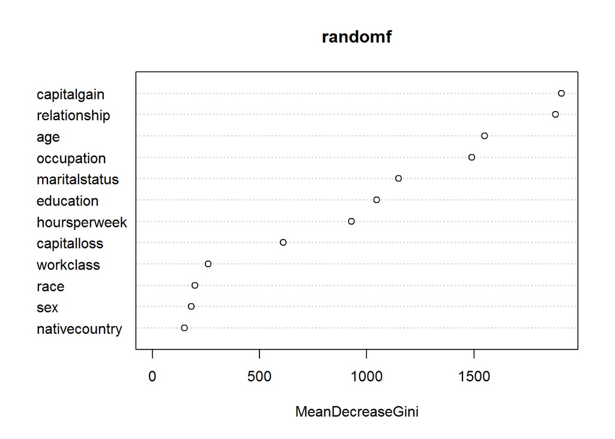

```r
varImpPlot(randomf,type=2)
```

using Cross validation to get the out of bag error, test error, sensitivity and specificity in case of training and test sample.

```r
Fullres<- NULL
nTries <- 30
for ( iTry in 1:nTries ) {
  Split <- sample.split(adultDat_Final$Income, SplitRatio = 0.75)
  Trainadult <- subset(adultDat_Final, Split == TRUE)
  Testadult <- subset(adultDat_Final, Split == FALSE)
  rf <- randomForest(Income~.,data=Trainadult)
  pred = predict(rf,Trainadult,type="response")
  predtest = predict(rf,Testadult,type="response")

  test <- assess.prediction(Trainadult$Income,pred)

  test1<-   assess.prediction(Testadult$Income,predtest)

  Fullres <- rbind(Fullres,data.frame(vars=iTry,sel="acc",val=c(1-rf$err.rate[nrow(rf$err.rate),"OOB"]
,test1[[1]]),traintest=c("Train","Test")))
  Fullres <- rbind(Fullres,data.frame(vars=iTry,sel="Sens",val=c(test[[2]],test1[[2]]),traintest=c("Train","Test")))
  Fullres <- rbind(Fullres,data.frame(vars=iTry,sel="Spec",val=c(test[[3]],test1[[3]]),traintest=c("Train","Test")))
}
```

```r
Rf_Train_avg_acc <- signif(sum(subset(Fullres,(traintest == "Train"&sel=="acc"))$val)*100/nTries,3)
Rf_Train_avg_sens <- signif(sum(subset(Fullres,(traintest == "Train"&sel=="Sens"))$val)*100/nTries,3)
Rf_Train_avg_spec <- signif(sum(subset(Fullres,(traintest == "Train"&sel=="Spec"))$val)*100/nTries,3)

Rf_Test_avg_acc <- signif(sum(subset(Fullres,(traintest == "Test"&sel=="acc"))$val)*100/nTries,3)
Rf_Test_avg_sens <- signif(sum(subset(Fullres,(traintest == "Test"&sel=="Sens"))$val)*100/nTries,3)
Rf_Test_avg_spec <- signif(sum(subset(Fullres,(traintest == "Test"&sel=="Spec"))$val)*100/nTries,3)
```

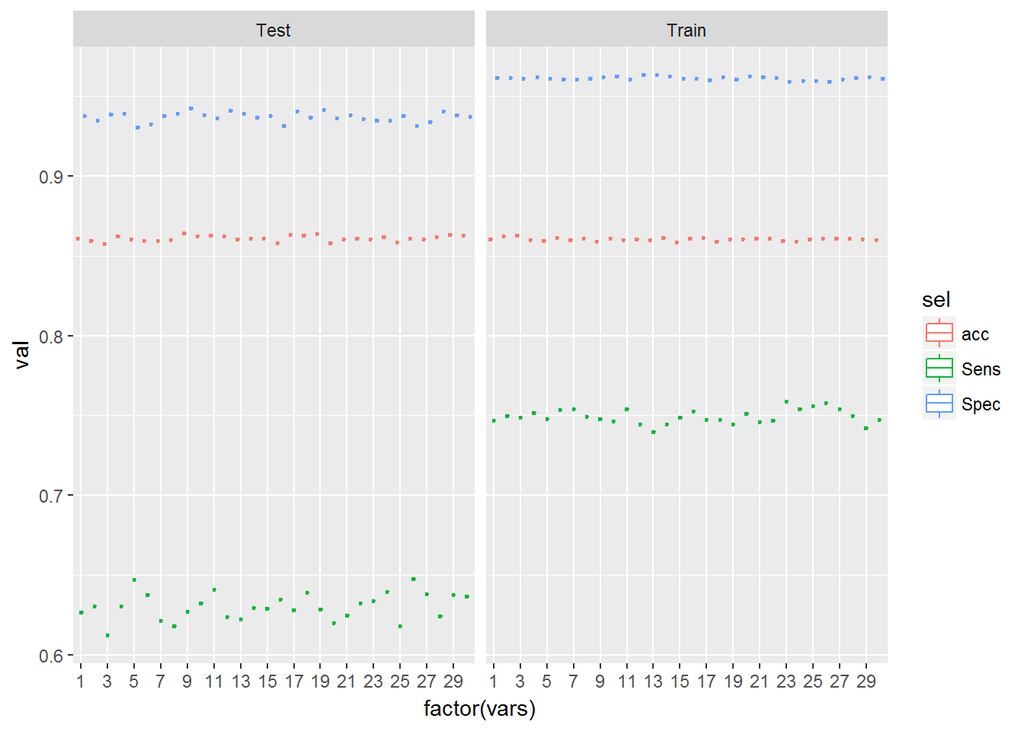

```r
ggplot(Fullres,aes(x=factor(vars),y=val,colour=sel)) + geom_boxplot()+facet_wrap(~traintest)+scale_x_discrete(breaks = seq(1, 30, by = 2))
```

```r
sprintf("Training Out of Bag, Sensitivity and Specificity of Logistic Regression are %g, %g, %g respective",Rf_Train_avg_acc,Rf_Train_avg_sens,Rf_Train_avg_spec)
```

```
## [1] "Training Out of Bag, Sensitivity and Specificity of Logistic Regression are 86.1, 74.9, 96.1 respective"
```

```r
sprintf("Testing Accuracy, Sensitivity and Specificity of Logistic Regression are %g, %g, %g respective",Rf_Test_avg_acc,Rf_Test_avg_sens,Rf_Test_avg_spec)
```

```
## [1] "Testing Accuracy, Sensitivity and Specificity of Logistic Regression are 86.1, 63, 93.7 respective"
```

The Training and Testing accuracy for Random Forest is better than Logistic regression. This model outperforms many models (Naive Bayes 83.88, NBTree 85.9, Knn 80) given in the dataset description.

# SVM

As the performance is hugely impacted by SVM. To choose the parameters only 10% of the records (approx 4500) are considered. The best performance model is obtained at cost =1 and gamma = 0.5

```r
test_data = adultDat_Final[sample(nrow(adultDat_Final), 4500), ]
```

```r
  tune.out=tune(svm, Income~., data=test_data, kernel="radial",ranges=list(cost=c(0.1,1,10,100),gamma=c(0.5,1,2,3)))
  print(tune.out$best.parameters)
```

```
##   cost gamma
## 2    1   0.5
```

```r
  print(tune.out$best.performance)
```

```
## [1] 0.1735556
```

Cross validation is done on 10 iterations, for 4500 random samples and test and train accuracy, sensitiviy and specificity are captured.

```r
test_data = adultDat_Final[sample(nrow(adultDat_Final), 4500), ]
Fullres<- NULL
nTries <- 10
for ( iTry in 1:nTries ) {
  Split <- sample.split(test_data$Income, SplitRatio = 0.75)
  Trainadult <- subset(test_data, Split == TRUE)
  Testadult <- subset(test_data, Split == FALSE)
  tune.out=tune(svm, Income~., data=test_data, kernel="radial",ranges=list(cost=c(1),gamma=c(0.5)))



  pred = predict(tune.out$best.model,newdata=Trainadult)
  predtest = predict(tune.out$best.model,newdata=Testadult)

  test <- assess.prediction(Trainadult$Income,pred)

  test1<-   assess.prediction(Testadult$Income,predtest)

  Fullres <- rbind(Fullres,data.frame(vars=iTry,sel="acc",val=c(test[[1]],test1[[1]]),traintest=c("Train","Test")))
  Fullres <- rbind(Fullres,data.frame(vars=iTry,sel="Sens",val=c(test[[2]],test1[[2]]),traintest=c("Train","Test")))
  Fullres <- rbind(Fullres,data.frame(vars=iTry,sel="Spec",val=c(test[[3]],test1[[3]]),traintest=c("Train","Test")))
}
```

```r
Svm_Train_avg_acc <- signif(sum(subset(Fullres,(traintest == "Train"&sel=="acc"))$val)*100/nTries,3)
Svm_Train_avg_sens <- signif(sum(subset(Fullres,(traintest == "Train"&sel=="Sens"))$val)*100/nTries,3)
Svm_Train_avg_spec <- signif(sum(subset(Fullres,(traintest == "Train"&sel=="Spec"))$val)*100/nTries,3)

Svm_Test_avg_acc <- signif(sum(subset(Fullres,(traintest == "Test"&sel=="acc"))$val)*100/nTries,3)
Svm_Test_avg_sens <- signif(sum(subset(Fullres,(traintest == "Test"&sel=="Sens"))$val)*100/nTries,3)
Svm_Test_avg_spec <- signif(sum(subset(Fullres,(traintest == "Test"&sel=="Spec"))$val)*100/nTries,3)
```

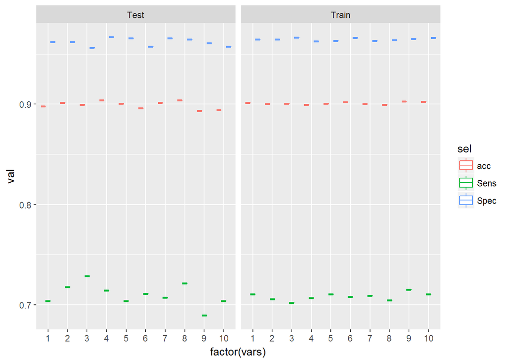

```r
ggplot(Fullres,aes(x=factor(vars),y=val,colour=sel)) + geom_boxplot()+facet_wrap(~traintest)
```

```r
sprintf("Training Accuracy, Sensitivity and Specificity of Logistic Regression are %g, %g, %g respective",Svm_Train_avg_acc,Svm_Train_avg_sens,Svm_Train_avg_spec)
```

```
## [1] "Training Accuracy, Sensitivity and Specificity of Logistic Regression are 90.1, 70.8, 96.5 respective"
```

```r
sprintf("Testing Accuracy, Sensitivity and Specificity of Logistic Regression are %g, %g, %g respective",Svm_Test_avg_acc,Svm_Test_avg_sens,Svm_Test_avg_spec)
```

```
## [1] "Testing Accuracy, Sensitivity and Specificity of Logistic Regression are 89.9, 71, 96.2 respective"
```

The accuracy for SVM is very high at 89%. This accuracy is better than all the models mentioned in the data set description. But the high accuracy can be debated as we took very small sample of the data because of performance issues.

# Comparing logistic regression, random forest and SVM model performance

Compare performance of the models developed above (logistic regression, random forest, SVM) in terms of their accuracy, error and sensitivity/specificity. Comment on differences and similarities between them.

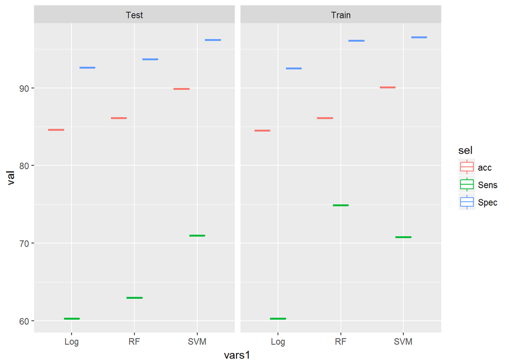

```r
Fullres1 <- NULL
Fullres1 <- rbind(Fullres1,data.frame(vars1="Log",sel="acc",val=c(Train_avg_acc,Test_avg_acc),traintest=c("Train","Test")))
Fullres1 <- rbind(Fullres1,data.frame(vars1="RF",sel="acc",val=c(Rf_Train_avg_acc,Rf_Test_avg_acc),traintest=c("Train","Test")))
Fullres1 <- rbind(Fullres1,data.frame(vars1="SVM",sel="acc",val=c(Svm_Train_avg_acc,Svm_Test_avg_acc),traintest=c("Train","Test")))
Fullres1 <- rbind(Fullres1,data.frame(vars1="Log",sel="Sens",val=c(Train_avg_sens,Test_avg_sens),traintest=c("Train","Test")))
Fullres1 <- rbind(Fullres1,data.frame(vars1="RF",sel="Sens",val=c(Rf_Train_avg_sens,Rf_Test_avg_sens),traintest=c("Train","Test")))
Fullres1 <- rbind(Fullres1,data.frame(vars1="SVM",sel="Sens",val=c(Svm_Train_avg_sens,Svm_Test_avg_sens),traintest=c("Train","Test")))
Fullres1 <- rbind(Fullres1,data.frame(vars1="Log",sel="Spec",val=c(Train_avg_spec,Test_avg_spec),traintest=c("Train","Test")))
Fullres1 <- rbind(Fullres1,data.frame(vars1="RF",sel="Spec",val=c(Rf_Train_avg_spec,Rf_Test_avg_spec),traintest=c("Train","Test")))
Fullres1 <- rbind(Fullres1,data.frame(vars1="SVM",sel="Spec",val=c(Svm_Train_avg_spec,Svm_Test_avg_spec),traintest=c("Train","Test")))
ggplot(Fullres1,aes(x=vars1,y=val,colour=sel)) + geom_boxplot()+facet_wrap(~traintest)
```